# What makes an NBA All-Star ?

### Analyzing All-Star Votes

By Nicolas Gold, Eric Wang, and Richard Lin

[figure not shown]

# Introduction

In the National Basketball Association (NBA), every season there is an All Star Game where the best players in the league play in a single game just for fun. The way these players are determined are by 3 sets of votes. The first set of votes come from the fans, the second set comes from the players in the league, and the third set of votes come from the NBA media. Whether you're a fan, a player, or a member of the media, you get a total of 5 votes (3 guards and 2 forwards). This project will focus on the player votes.

Using player statistics from last year's season, we will first see which how many votes each player got last season. Then we will use the player statistics and the votes they recieved to see which stats (such as points per game, or rebounds per game) other NBA players value the most in voting so we can get a better idea of what makes up an NBA All Star. We will also use Machine Learning to compare the effect of player statistics on Ratings and Votes. As, it seems to be a universal arguement that the most skilled players are also the most popular players.

### 1. Getting Started

- 1.1 Libraries
- 1.2 Extracting the Data
- 1.3 Merging the Data
- 1.4 Isolating Columns and Top 200 Players

### 2. Exploring Top 200 Players

- 2.1 Averages of Top 200 vs Top 10 by Position
- 2.2 Comparing the Top 200 and Top 10 Players by Position
- 2.3 Further Analyzing Top 200 Players by Position and Conference

### 3. Exploring Potential Outliers

- 3.1 Total Amount of Players within Different Brackets of All Star Voting
- 3.2 Analyzing Giannis Antetokounmpo

### 4. Linear Regression for Attributes on Rating and Votes

- 4.1 Linear Regression Models for Ratings and Votes
- 4.2 Prediction of Ratings vs Prediction of Votes

### 5. Conclusion

- 5.1 Top 200 Players
- 5.2 Potential Outliers
- 5.3 Regression Analysis (Ratings vs Votes)

# 1. Getting Started

## 1.1 Libraries

#### requests:

For HTTP requests

#### numpy:

For containing data

#### re:

For regular expressions

#### datetime:

For date and time objects

#### matplotlib/seaborn:

For plotting

#### html5lib:

For parsing HTML

#### pandas:

For data manipulation

#### sklearn:

For Machine Learning

```python
import requests
import numpy as np
import re
from bs4 import BeautifulSoup
import datetime as dt
import matplotlib.pyplot as plt; plt.rcdefaults()
import matplotlib.pyplot as plt
from matplotlib.gridspec import GridSpec
import seaborn as sns
import sklearn
import html5lib
import pandas as pd
from sklearn.linear_model import LinearRegression
from sklearn.linear_model import LogisticRegression
from sklearn.model_selection import train_test_split
```

## 1.2 Extracting the Data

There are 3 different sets of data that we will be extracting for this project:

- Data Set 1: Player's and their Statistics (main Data Set)
- Data Set 2: NBA 2K Player Ratings
- Data Set 3: Player All Star Votes

#### Data Set 1: Player's and their Statistics:

- This Data Set contains all the NBA players from the 2018-2019 NBA Season
- For each player, it contains basic attributes for the player such as Team, Height, Weight, Age, etc.
- Along with the attrivutes, it contains the players averages for each game of the season, such as Point, Rebounds, Assists, Steals, Field Goal Percentage, etc.
- Link to the Kaggle Data Set is here: https://www.kaggle.com/mcamli/nba17-18#nba_extra.csv. Important thing to note, the name of the file says "2017-2018" but it is really the 2018-2019 Season. The file is nba_extra.csv

```python
NBA_Players = pd.read_csv("nbastats2018-2019.csv", sep=',')
NBA_Players = NBA_Players.dropna()

pd.set_option('display.max_columns', None)
pd.set_option('display.max_rows', None)
pd.set_option('display.max_colwidth', -1)
NBA_Players.head(10)
```

|  | Name | Height | Weight | Team | Age | Salary | Points | Blocks | Steals | Assists | Rebounds | FT% | FTA | FG3% | FG3A | FG% | FGA | MP | G | PER | OWS | DWS | WS | WS48 | USG | BPM | VORP |
| --- | --- | --- | --- | --- | --- | --- | --- | --- | --- | --- | --- | --- | --- | --- | --- | --- | --- | --- | --- | --- | --- | --- | --- | --- | --- | --- | --- |
| 0 | Alex Abrines | 78 | 200 | Oklahoma City Thunder | 25 | 5455236 | 5.3 | 0.2 | 0.5 | 0.6 | 1.5 | 0.923 | 0.4 | 0.323 | 4.1 | 0.357 | 5.1 | 19.0 | 31 | 6.3 | 0.1 | 0.6 | 0.6 | 0.053 | 12.2 | -3.4 | -0.2 |
| 1 | Quincy Acy | 79 | 240 | Phoenix Suns | 28 | 213949 | 1.7 | 0.4 | 0.1 | 0.8 | 2.5 | 0.700 | 1.0 | 0.133 | 1.5 | 0.222 | 1.8 | 12.3 | 10 | 2.9 | -0.1 | 0.0 | -0.1 | -0.022 | 9.2 | -5.9 | -0.1 |
| 2 | Jaylen Adams | 74 | 190 | Atlanta Hawks | 22 | 236854 | 3.2 | 0.1 | 0.4 | 1.9 | 1.8 | 0.778 | 0.3 | 0.338 | 2.2 | 0.345 | 3.2 | 12.6 | 34 | 7.6 | -0.1 | 0.2 | 0.1 | 0.011 | 13.5 | -4.4 | -0.3 |
| 3 | Steven Adams | 84 | 265 | Oklahoma City Thunder | 25 | 24157304 | 13.9 | 1.0 | 1.5 | 1.6 | 9.5 | 0.500 | 3.7 | 0.000 | 0.0 | 0.595 | 10.1 | 33.4 | 80 | 18.5 | 5.1 | 4.0 | 9.1 | 0.163 | 16.4 | 2.7 | 3.2 |
| 4 | Bam Adebayo | 82 | 255 | Miami Heat | 21 | 2955840 | 8.9 | 0.8 | 0.9 | 2.2 | 7.3 | 0.735 | 2.8 | 0.200 | 0.2 | 0.576 | 5.9 | 23.3 | 82 | 17.9 | 3.4 | 3.4 | 6.8 | 0.171 | 15.8 | 3.0 | 2.4 |
| 6 | LaMarcus Aldridge | 83 | 260 | San Antonio Spurs | 33 | 22347015 | 21.3 | 1.3 | 0.5 | 2.4 | 9.2 | 0.847 | 5.1 | 0.238 | 0.5 | 0.519 | 16.3 | 33.2 | 81 | 22.9 | 6.4 | 2.9 | 9.3 | 0.167 | 26.9 | 1.6 | 2.5 |
| 8 | Grayson Allen | 77 | 198 | Utah Jazz | 23 | 2074320 | 5.6 | 0.2 | 0.2 | 0.7 | 0.6 | 0.750 | 1.6 | 0.323 | 2.6 | 0.376 | 4.7 | 10.9 | 38 | 7.5 | -0.4 | 0.4 | 0.0 | 0.002 | 24.4 | -6.8 | -0.5 |
| 9 | Jarrett Allen | 83 | 237 | Brooklyn Nets | 20 | 2034120 | 10.9 | 1.5 | 0.5 | 1.4 | 8.4 | 0.709 | 3.5 | 0.133 | 0.6 | 0.590 | 7.1 | 26.2 | 80 | 18.5 | 4.4 | 3.3 | 7.6 | 0.175 | 15.9 | 2.5 | 2.4 |
| 11 | Al-Farouq Aminu | 81 | 220 | Portland Trail Blazers | 28 | 6957105 | 9.4 | 0.4 | 0.8 | 1.3 | 7.5 | 0.867 | 2.1 | 0.343 | 3.5 | 0.433 | 7.3 | 28.3 | 81 | 13.2 | 3.0 | 2.8 | 5.8 | 0.121 | 13.7 | 0.9 | 1.7 |
| 12 | Justin Anderson | 78 | 230 | Atlanta Hawks | 25 | 2516048 | 3.7 | 0.3 | 0.5 | 0.5 | 1.8 | 0.743 | 0.7 | 0.312 | 1.6 | 0.408 | 3.3 | 9.6 | 48 | 11.2 | 0.1 | 0.4 | 0.4 | 0.043 | 17.2 | -3.3 | -0.1 |

#### Data Set 2: NBA 2K Player Ratings:

- These are Player ratings taken from the NBA based video game NBA 2K19
- These ratings are from 0 (being the worst) to 99 (being the best)
- The ratings are based by predetermined attributes that are not depicted in the data set
- The purpose of these ratings is to give a quantitive value to how good a player is, so we can order the players from best to worst if need be.
- Link to the Kaggle Data Set is here: https://www.kaggle.com/stormex/nba-2019-ratings

```python
Ratings = pd.read_csv("Nba 19 ratings.csv", sep=',')
Ratings = Ratings.loc[:, ~Ratings.columns.str.contains('^Unnamed')]
Ratings.columns = ['Name', 'Rating']
Ratings.head(10)
```

|  | Name | Rating |
| --- | --- | --- |
| 0 | Kent Bazemore | 76 |
| 1 | Dewayne Dedmon | 77 |
| 2 | John Collins | 84 |
| 3 | Miles Plumlee | 71 |
| 4 | DeAndre’ Bembry | 72 |
| 5 | Taurean Prince | 77 |
| 6 | Trae Young | 84 |
| 7 | Kevin Huerter | 74 |
| 8 | Omari Spellman | 73 |
| 9 | Justin Anderson | 72 |

#### Data Set 3: Player All Star Votes

- This data is scraped off of the website https://www.basketball-reference.com/allstar/NBA_2019_voting-backcourt-eastern-conference.html.
- On the website there are four tabs. Two for each conference and in each conference it is split between forwards and guards
- Each data set contains votes from fans, players, and media. We will be using the player votes.
- In this data set, we will also get which conference (East or West) and which position each player is.

```python
urls = [["https://www.basketball-reference.com/allstar/NBA_2019_voting-frontcourt-eastern-conference.html","East","Forward"],
       ["https://www.basketball-reference.com/allstar/NBA_2019_voting-frontcourt-western-conference.html","West","Forward"],
       ["https://www.basketball-reference.com/allstar/NBA_2019_voting-backcourt-eastern-conference.html","East","Guard"],
       ["https://www.basketball-reference.com/allstar/NBA_2019_voting-backcourt-western-conference.html","West","Guard"]]

players = []
votes = []
position = []
conference = []
for val in urls:
    url = val[0]
    conf = val[1]
    pos = val[2]
    r = requests.get(url).text
    soup = BeautifulSoup(r ,'lxml')
    table = soup.find('table')
    list_of_rows = []
    for row in table.findAll('tr'):
        list_of_cells = []
        for cell in row.findAll(["th","td"]):
            text = cell.text
            list_of_cells.append(text)
        list_of_rows.append(list_of_cells)
    list_of_rows.pop(0)
    list_of_rows.pop(0)

    for player in list_of_rows:
        players.append(player[1])
        votes.append(player[5])
        conference.append(conf)
        position.append(pos)

Player_Votes = pd.DataFrame()
Player_Votes['Name'] = players
Player_Votes['Votes'] = votes
Player_Votes['Position'] = position
Player_Votes['Conference'] = conference
Player_Votes.head(10)
```

|  | Name | Votes | Position | Conference |
| --- | --- | --- | --- | --- |
| 0 | Giannis Antetokounmpo | 269 | Forward | East |
| 1 | Kawhi Leonard | 189 | Forward | East |
| 2 | Joel Embiid | 186 | Forward | East |
| 3 | Jayson Tatum | 19 | Forward | East |
| 4 | Pascal Siakam | 16 | Forward | East |
| 5 | Nikola Vučević | 17 | Forward | East |
| 6 | Jimmy Butler | 51 | Forward | East |
| 7 | Blake Griffin | 50 | Forward | East |
| 8 | Vince Carter | 11 | Forward | East |
| 9 | Andre Drummond | 21 | Forward | East |

## 1.3 Merging the Data

Now that we have the three data sets, we can merge them all together on the column 'Name'. We will also sort the values by votes.

```python
Complete_Data = pd.merge(NBA_Players, pd.merge(Ratings, Player_Votes, on='Name'), on='Name')
Complete_Data.Votes = Complete_Data.Votes.astype(float)
Complete_Data = Complete_Data.sort_values(by = ['Votes'], ascending = False)
Complete_Data.head(10)
```

|  | Name | Height | Weight | Team | Age | Salary | Points | Blocks | Steals | Assists | Rebounds | FT% | FTA | FG3% | FG3A | FG% | FGA | MP | G | PER | OWS | DWS | WS | WS48 | USG | BPM | VORP | Rating | Votes | … |
| --- | --- | --- | --- | --- | --- | --- | --- | --- | --- | --- | --- | --- | --- | --- | --- | --- | --- | --- | --- | --- | --- | --- | --- | --- | --- | --- | --- | --- | --- | --- |
| 9 | Giannis Antetokounmpo | 83 | 242 | Milwaukee Bucks | 24 | 24157304 | 27.7 | 1.5 | 1.3 | 5.9 | 12.5 | 0.729 | 9.5 | 0.256 | 2.8 | 0.578 | 17.3 | 32.8 | 72 | 30.9 | 8.9 | 5.5 | 14.4 | 0.292 | 32.3 | 10.8 | 7.6 | 96 | 269.0 | … |
| 173 | Kyrie Irving | 75 | 193 | Boston Celtics | 26 | 20099189 | 23.8 | 0.5 | 1.5 | 6.9 | 5.0 | 0.873 | 3.7 | 0.401 | 6.5 | 0.487 | 18.5 | 33.0 | 67 | 24.3 | 6.2 | 2.9 | 9.1 | 0.197 | 29.6 | 6.4 | 4.7 | 92 | 190.0 | … |
| 210 | Kawhi Leonard | 79 | 230 | Toronto Raptors | 27 | 23114067 | 26.6 | 0.4 | 1.8 | 3.3 | 7.3 | 0.854 | 7.1 | 0.371 | 5.0 | 0.496 | 18.8 | 34.0 | 60 | 25.8 | 6.1 | 3.4 | 9.5 | 0.224 | 30.3 | 5.0 | 3.6 | 95 | 189.0 | … |
| 106 | Joel Embiid | 84 | 250 | Philadelphia 76ers | 24 | 25467250 | 27.5 | 1.9 | 0.7 | 3.7 | 13.6 | 0.804 | 10.1 | 0.300 | 4.1 | 0.484 | 18.7 | 33.7 | 64 | 26.1 | 4.9 | 3.8 | 8.7 | 0.194 | 33.3 | 4.1 | 3.3 | 93 | 186.0 | … |
| 181 | LeBron James | 80 | 250 | Los Angeles Lakers | 34 | 35654150 | 27.4 | 0.6 | 1.3 | 8.3 | 8.5 | 0.665 | 7.6 | 0.339 | 5.9 | 0.510 | 19.9 | 35.2 | 55 | 25.6 | 4.7 | 2.6 | 7.2 | 0.179 | 31.6 | 8.1 | 4.9 | 96 | 174.0 | … |
| 103 | Kevin Durant | 81 | 240 | Golden State Warriors | 30 | 30000000 | 26.0 | 1.1 | 0.7 | 5.9 | 6.4 | 0.885 | 6.5 | 0.353 | 5.0 | 0.521 | 17.7 | 34.6 | 78 | 24.2 | 8.6 | 2.9 | 11.5 | 0.204 | 29.0 | 4.3 | 4.3 | 95 | 168.0 | … |
| 84 | Stephen Curry | 75 | 190 | Golden State Warriors | 30 | 37457154 | 27.3 | 0.4 | 1.3 | 5.2 | 5.3 | 0.916 | 4.2 | 0.437 | 11.7 | 0.472 | 19.4 | 33.8 | 69 | 24.4 | 7.2 | 2.5 | 9.7 | 0.199 | 30.4 | 6.3 | 4.9 | 95 | 161.0 | … |
| 144 | James Harden | 77 | 220 | Houston Rockets | 29 | 30431854 | 36.1 | 0.7 | 2.0 | 7.5 | 6.6 | 0.879 | 11.0 | 0.368 | 13.2 | 0.442 | 24.5 | 36.8 | 78 | 30.6 | 11.4 | 3.8 | 15.2 | 0.254 | 40.5 | 11.7 | 9.9 | 96 | 153.0 | … |
| 86 | Anthony Davis | 82 | 253 | New Orleans Pelicans | 25 | 25434263 | 25.9 | 2.4 | 1.6 | 3.9 | 12.0 | 0.794 | 7.7 | 0.331 | 2.6 | 0.517 | 18.3 | 33.0 | 56 | 30.3 | 6.4 | 3.1 | 9.5 | 0.247 | 29.5 | 8.5 | 4.9 | 94 | 136.0 | … |
| 339 | Kemba Walker | 73 | 184 | Charlotte Hornets | 28 | 12000000 | 25.6 | 0.4 | 1.2 | 5.9 | 4.4 | 0.844 | 5.5 | 0.356 | 8.9 | 0.434 | 20.5 | 34.9 | 82 | 21.7 | 5.5 | 1.9 | 7.4 | 0.123 | 31.5 | 3.3 | 3.9 | 88 | 98.0 | … |

## 1.4 Isolating Columns and Top 200 Players

Furthermore, there are some variables in Complete_Data that are not necessary for the remainder of the project. So we will remove these variables. The variables that we will be using are:

- Name
- Position
- Conference
- Votes
- Rating
- Points
- Rebounds
- Assists
- Blocks
- Steals
- Field Goal Percentage
- 3 Point Percentage
- Free Throw Percentage
- Player Efficiency Rating

It is important to note that all the variables from Points to Player Efficieny Rating are an average over each game, not totals for the season

```python
Complete_Data = Complete_Data[['Name', 'Position', 'Conference', 'Votes', 'Rating', 'Points', 'Rebounds', 'Assists', 'Blocks', 'Steals', 'FG%', 'FG3%', 'FT%', 'PER']]
Top_200_Players = Complete_Data.head(200)
Top_200_Players.head(10)
```

|  | Name | Position | Conference | Votes | Rating | Points | Rebounds | Assists | Blocks | Steals | FG% | FG3% | FT% | PER |
| --- | --- | --- | --- | --- | --- | --- | --- | --- | --- | --- | --- | --- | --- | --- |
| 9 | Giannis Antetokounmpo | Forward | East | 269.0 | 96 | 27.7 | 12.5 | 5.9 | 1.5 | 1.3 | 0.578 | 0.256 | 0.729 | 30.9 |
| 173 | Kyrie Irving | Guard | East | 190.0 | 92 | 23.8 | 5.0 | 6.9 | 0.5 | 1.5 | 0.487 | 0.401 | 0.873 | 24.3 |
| 210 | Kawhi Leonard | Forward | East | 189.0 | 95 | 26.6 | 7.3 | 3.3 | 0.4 | 1.8 | 0.496 | 0.371 | 0.854 | 25.8 |
| 106 | Joel Embiid | Forward | East | 186.0 | 93 | 27.5 | 13.6 | 3.7 | 1.9 | 0.7 | 0.484 | 0.300 | 0.804 | 26.1 |
| 181 | LeBron James | Forward | West | 174.0 | 96 | 27.4 | 8.5 | 8.3 | 0.6 | 1.3 | 0.510 | 0.339 | 0.665 | 25.6 |
| 103 | Kevin Durant | Forward | West | 168.0 | 95 | 26.0 | 6.4 | 5.9 | 1.1 | 0.7 | 0.521 | 0.353 | 0.885 | 24.2 |
| 84 | Stephen Curry | Guard | West | 161.0 | 95 | 27.3 | 5.3 | 5.2 | 0.4 | 1.3 | 0.472 | 0.437 | 0.916 | 24.4 |
| 144 | James Harden | Guard | West | 153.0 | 96 | 36.1 | 6.6 | 7.5 | 0.7 | 2.0 | 0.442 | 0.368 | 0.879 | 30.6 |
| 86 | Anthony Davis | Forward | West | 136.0 | 94 | 25.9 | 12.0 | 3.9 | 2.4 | 1.6 | 0.517 | 0.331 | 0.794 | 30.3 |
| 339 | Kemba Walker | Guard | East | 98.0 | 88 | 25.6 | 4.4 | 5.9 | 0.4 | 1.2 | 0.434 | 0.356 | 0.844 | 21.7 |

# 2. Exploring Top 200 Players

## 2.1 Averages of Top 200 vs Top 10 by Position

Now that we have the Top 200 vote getters, we can now explore these players. What we will be doing first is dividing up the Top 200 players by position. First we will get all the guards and put them into a dataframe. Then we will further analyze the top 10 guards and compare them to the rest of the guards. After we analyze the guards, we will repeat the process for the forwards.

### All Guards in the Top 200

```python
Guards_In_Top_200 = Top_200_Players[Top_200_Players['Position'] == "Guard"]
print("There are " + str(len(Guards_In_Top_200)) + " Guards in the Top 200 Players")
Guards_In_Top_200.mean().reset_index()
```

```
There are 83 Guards in the Top 200 Players
```

|  | index | 0 |
| --- | --- | --- |
| 0 | Votes | 16.445783 |
| 1 | Rating | 79.337349 |
| 2 | Points | 13.787952 |
| 3 | Rebounds | 3.554217 |
| 4 | Assists | 3.972289 |
| 5 | Blocks | 0.318072 |
| 6 | Steals | 0.937349 |
| 7 | FG% | 0.433783 |
| 8 | FG3% | 0.346060 |
| 9 | FT% | 0.794506 |
| 10 | PER | 14.702410 |

### Top 10 Guards

```python
Top_10_Guards = Guards_In_Top_200.head(10)
Top_10_Guards = Top_10_Guards[Top_10_Guards['Position'] == "Guard"]
Top_10_Guards.mean().reset_index()
```

|  | index | 0 |
| --- | --- | --- |
| 0 | Votes | 89.8000 |
| 1 | Rating | 88.9000 |
| 2 | Points | 22.6200 |
| 3 | Rebounds | 6.0600 |
| 4 | Assists | 6.7500 |
| 5 | Blocks | 0.5300 |
| 6 | Steals | 1.4700 |
| 7 | FG% | 0.4568 |
| 8 | FG3% | 0.3223 |
| 9 | FT% | 0.7844 |
| 10 | PER | 21.2800 |

### Bar Plot of Top 10 Guards

Next we will put the Top 10 guards on a bar plot so it is easier to visualize the votes and compare them to each other.

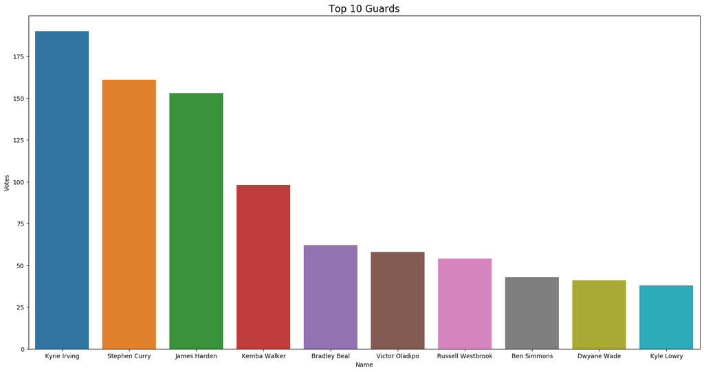

```python
plt.figure(figsize=(20,10))
plt.title("Top 10 Guards", fontsize=16)
sns.barplot(data=Top_10_Guards, x='Name', y='Votes')
plt.show()
```

### All Forwards in the Top 200

```python
Forwards_In_Top_200 = Top_200_Players[Top_200_Players['Position'] == "Forward"]
print("There are " + str(len(Forwards_In_Top_200)) + " Forwards in the Top 200 Players")
Forwards_In_Top_200.mean().reset_index()
```

```
There are 117 Forwards in the Top 200 Players
```

|  | index | 0 |
| --- | --- | --- |
| 0 | Votes | 16.282051 |
| 1 | Rating | 78.940171 |
| 2 | Points | 12.162393 |
| 3 | Rebounds | 5.881197 |
| 4 | Assists | 2.091453 |
| 5 | Blocks | 0.713675 |
| 6 | Steals | 0.757265 |
| 7 | FG% | 0.479265 |
| 8 | FG3% | 0.315222 |
| 9 | FT% | 0.742291 |
| 10 | PER | 15.739316 |

### Top 10 Forwards

```python
Top_10_Forwards = Forwards_In_Top_200.head(10)
Top_10_Forwards = Top_10_Forwards[Top_10_Forwards['Position'] == "Forward"]
Top_10_Forwards.mean().reset_index()
```

|  | index | 0 |
| --- | --- | --- |
| 0 | Votes | 134.8000 |
| 1 | Rating | 92.5000 |
| 2 | Points | 25.3600 |
| 3 | Rebounds | 9.0500 |
| 4 | Assists | 4.6900 |
| 5 | Blocks | 1.0600 |
| 6 | Steals | 1.2700 |
| 7 | FG% | 0.4987 |
| 8 | FG3% | 0.3283 |
| 9 | FT% | 0.8025 |
| 10 | PER | 25.0300 |

Similarly to the guards, the top 10 forwards are much better than the top 200 forwards. Some of the data points that are interesting is there is not a noticeable difference between FG3% between the top 20 and top 200 forwards. But again, overall all of the averages are higher in the top 10 forwards.

### Bar Plot of Top 10 Forwards

Next we will put the Top 10 forwards on a bar plot so it is easier to visualize the votes and compare them to each other.

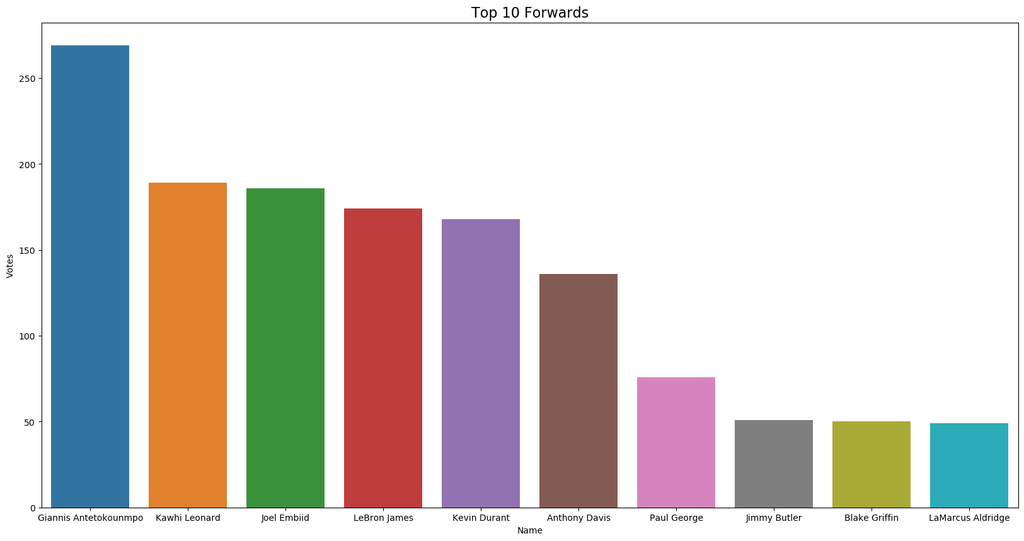

```python
plt.figure(figsize=(20,10))
plt.title("Top 10 Forwards", fontsize=16)
sns.barplot(data=Top_10_Forwards, x='Name', y='Votes')
plt.show()
```

## 2.2 Comparing the Top 200 and Top 10 Players by Position

Now that we have four different dataframes of all the guards and forwards and the top 10s of each respectively, it is time to compare them all. We will be doing this by creating a box plot for each of the ten statistics in Top_200_Players. We feel looking at box plots best allows us to compare the data to each other.

These are the statistics we will be looking at first in order:

- Points
- Rebounds
- Assists
- Blocks
- Steals
- Rating

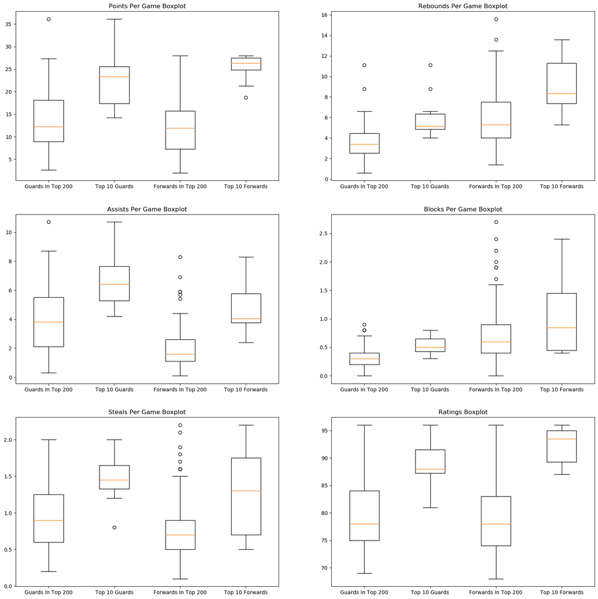

```python
fig, axes = plt.subplots(3, 2, figsize=(20,20))
axes[0, 0].boxplot([Guards_In_Top_200['Points'], Top_10_Guards['Points'], Forwards_In_Top_200['Points'], Top_10_Forwards['Points']], labels=['Guards In Top 200', 'Top 10 Guards', 'Forwards In Top 200','Top 10 Forwards'])
axes[0, 0].set_title("Points Per Game Boxplot")
axes[0, 1].boxplot([Guards_In_Top_200['Rebounds'], Top_10_Guards['Rebounds'], Forwards_In_Top_200['Rebounds'], Top_10_Forwards['Rebounds']], labels=['Guards In Top 200', 'Top 10 Guards', 'Forwards In Top 200','Top 10 Forwards'])
axes[0, 1].set_title("Rebounds Per Game Boxplot")
axes[1, 0].boxplot([Guards_In_Top_200['Assists'], Top_10_Guards['Assists'], Forwards_In_Top_200['Assists'], Top_10_Forwards['Assists']], labels=['Guards In Top 200', 'Top 10 Guards', 'Forwards In Top 200','Top 10 Forwards'])
axes[1, 0].set_title("Assists Per Game Boxplot")
axes[1, 1].boxplot([Guards_In_Top_200['Blocks'], Top_10_Guards['Blocks'], Forwards_In_Top_200['Blocks'], Top_10_Forwards['Blocks']], labels=['Guards In Top 200', 'Top 10 Guards', 'Forwards In Top 200','Top 10 Forwards'])
axes[1, 1].set_title("Blocks Per Game Boxplot")
axes[2, 0].boxplot([Guards_In_Top_200['Steals'], Top_10_Guards['Steals'], Forwards_In_Top_200['Steals'], Top_10_Forwards['Steals']], labels=['Guards In Top 200', 'Top 10 Guards', 'Forwards In Top 200','Top 10 Forwards'])
axes[2, 0].set_title("Steals Per Game Boxplot")
axes[2, 1].boxplot([Guards_In_Top_200['Rating'], Top_10_Guards['Rating'], Forwards_In_Top_200['Rating'], Top_10_Forwards['Rating']], labels=['Guards In Top 200', 'Top 10 Guards', 'Forwards In Top 200','Top 10 Forwards'])
axes[2, 1].set_title("Ratings Boxplot")
plt.show()
```

As it is predicted, the Top 10 categories tend to have higher averages then rest of their respective position. This is especially the case with Points and Ratings. We can also see how certain positions tend to have higher values in a certain category than others. For example, forwards tend to have higher averages in rebounds and blocks while guards tend to have higher values in assists and steals. One interesting thing to compare is within rebounds and assists. For rebounds, the top 10 guards have around the same average of rebounds as all the forwards. The opposite is the case with the assists, the top 10 fowards have around the same average of assists as all the guards. It will be interesting to see this difference play out when we do our Linear Regression later.

These are the next four statistics we will look at:

- Field Goal Percentage
- 3 Point Percentage
- Free Throw Percentage
- Player Efficiency Rating

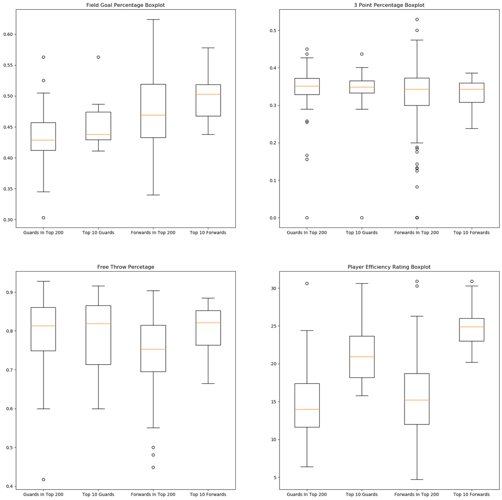

```python
fig, axes = plt.subplots(2, 2, figsize=(20,20))
axes[0, 0].boxplot([Guards_In_Top_200['FG%'], Top_10_Guards['FG%'], Forwards_In_Top_200['FG%'], Top_10_Forwards['FG%']], labels=['Guards In Top 200', 'Top 10 Guards', 'Forwards In Top 200','Top 10 Forwards'])
axes[0, 0].set_title("Field Goal Percentage Boxplot")
axes[0, 1].boxplot([Guards_In_Top_200['FG3%'], Top_10_Guards['FG3%'], Forwards_In_Top_200['FG3%'], Top_10_Forwards['FG3%']], labels=['Guards In Top 200', 'Top 10 Guards', 'Forwards In Top 200','Top 10 Forwards'])
axes[0, 1].set_title("3 Point Percentage Boxplot")
axes[1, 0].boxplot([Guards_In_Top_200['FT%'], Top_10_Guards['FT%'], Forwards_In_Top_200['FT%'], Top_10_Forwards['FT%']], labels=['Guards In Top 200', 'Top 10 Guards', 'Forwards In Top 200','Top 10 Forwards'])
axes[1, 0].set_title("Free Throw Percetage")
axes[1, 1].boxplot([Guards_In_Top_200['PER'], Top_10_Guards['PER'], Forwards_In_Top_200['PER'], Top_10_Forwards['PER']], labels=['Guards In Top 200', 'Top 10 Guards', 'Forwards In Top 200','Top 10 Forwards'])
axes[1, 1].set_title("Player Efficiency Rating Boxplot")
plt.show()
```

The Player Efficiency Rating chart is nothing surprising, usually the top platers have a higher PER anyway. The other interesting thing to note is that when it comes to the three percentages statistics, it seems like those do not matter as much, considering they are are all close to even across the board.

## 2.3 Further Analyzing Top 200 Players by Position and Conference

For this part, we will be diving deeper into the top 200 players. First we looked at each position and now we will look at players and conference. One may initially think that conference doesn't matter, but it may have an affect. In the NBA, the Western Conference is significantly better than the Eastern Conference. So we may see the statistics for the western conference be a little bit higher. Instead of using a bar plot, we will use a violin part instead. This allows for further information that a bar plot does not.

The Statistics we will be looking at are:

- Points
- Rebounds
- Assists
- Blocks
- Steals

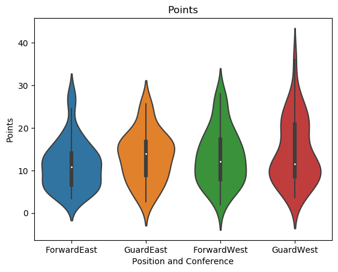

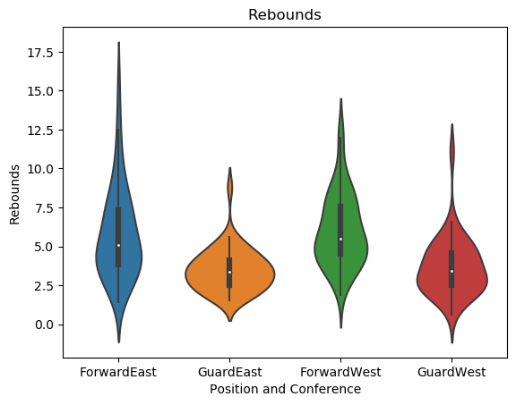

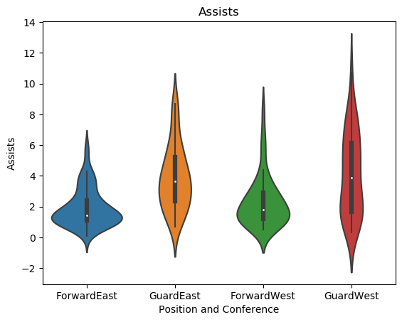

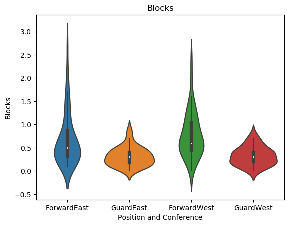

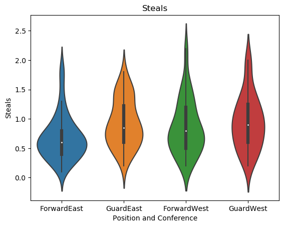

```python
Top_200_Players_Divided = pd.DataFrame(Top_200_Players)
Top_200_Players_Divided['Position and Conference'] = Top_200_Players_Divided[['Position', 'Conference']].apply(lambda x: ''.join(x), axis=1)

vplot1 = sns.violinplot(x="Position and Conference", y="Points", data=Top_200_Players_Divided)
plt.title("Points")
plt.show(vplot1)

vplot2 = sns.violinplot(x="Position and Conference", y="Rebounds", data=Top_200_Players_Divided)
plt.title("Rebounds")
plt.show(vplot2)

vplot3 = sns.violinplot(x="Position and Conference", y="Assists", data=Top_200_Players_Divided)
plt.title("Assists")
plt.show(vplot3)

vplot4 = sns.violinplot(x="Position and Conference", y="Blocks", data=Top_200_Players_Divided)
plt.title("Blocks")
plt.show(vplot4)

vplot5 = sns.violinplot(x="Position and Conference", y="Steals", data=Top_200_Players_Divided)
plt.title("Steals")
plt.show(vplot5)
```

It seems the prediction we made was partically accurate. When you compare the guards, it appears that the guards in the west seem to be a tad bit larger in the west than the east. The difference is very minimal however. On the other hand, the same cannot be said for the forwards. The statistics for the farwards in each conference appear very similar. In fact, the east forwards have a smaller advantage than the west does in Rebounding. We can conclude that conference does not really make a difference in player stats, so conference is not something that we will focus on.

# 3. Exploring Potential Outliers

In this section, we will look at the distribution of all star voting and see if there are any players that are worth further analyzing

## 3.1 Total Amount of Players within Different Brackets of All Star Voting

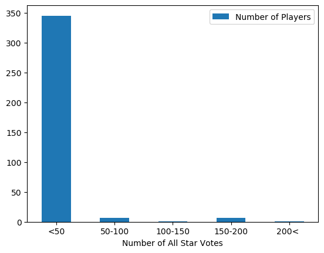

```python
Over_200 = Complete_Data[(Complete_Data['Votes'] > 200)]
Between_200_150 = Complete_Data[(Complete_Data['Votes']< 200) &(Complete_Data['Votes']>=150)]
Between_150_100 = Complete_Data[(Complete_Data['Votes']< 150) &(Complete_Data['Votes']>=100)]
Between_100_50 = Complete_Data[(Complete_Data['Votes']< 100) &(Complete_Data['Votes']>=50)]
Between_50_0 = Complete_Data[(Complete_Data['Votes']< 50) &(Complete_Data['Votes']>=0)]

vals = [len(Between_50_0), len(Between_100_50), len(Between_150_100), len(Between_200_150), len(Over_200)]
df = pd.DataFrame({'Number of All Star Votes':['<50', '50-100', '100-150','150-200','200< '], 'Number of Players':vals})
ax = df.plot.bar(x='Number of All Star Votes', y='Number of Players', rot=0)
```

Based off this graph, what we have discovered that most players recieve less than 50 all star votes and there exists very few players who recieve more than 150 (Only 8!) . However, what this graph also tells us is that there is only one player who recieved more than 200 votes and that is Giannis Antetokounmpo.

## 3.2 Analyzing Giannis Antetokounmpo

In the last graph, we found out that Giannis was the only player who recieved more than 200 votes. Thus, lets now compare him to other players with respect to the amount of points scored and total rebounds. In addition, we will compare him to other players with respect to the amount of points scored and total assists.

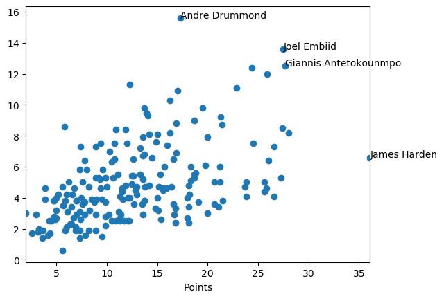

```python
def label_point(x, y, val, ax):
        a = pd.concat({'Points': x, 'Rebounds': y, 'Name': val}, axis=1)
        for i, point in a.iterrows():
            if(point['Name'] == 'Giannis Antetokounmpo' or point['Name'] == 'Andre Drummond' or point['Name'] == 'Joel Embiid' or point['Name'] == 'James Harden' ):
                ax.text(point['Points'], point['Rebounds'], str(point['Name']))


Top_200_Players = Complete_Data.head(200)

ax = Top_200_Players.set_index('Points')['Rebounds'].plot(style='o')
label_point(Top_200_Players.Points, Top_200_Players.Rebounds, Top_200_Players.Name, ax)
fig.canvas.draw()
```

This scatter plot produces some very interesting information. Joel Embiid scores slightly less than Giannis, but he gets rebounds. In addition, James Harden clearly scores the most points, and Andre Drummond gets the most rebounds. However, Giannis still has around 80 more votes compared to the second most vote getter, and 83 more than Joel Embiid despite the similar statistics in rebounding and points!

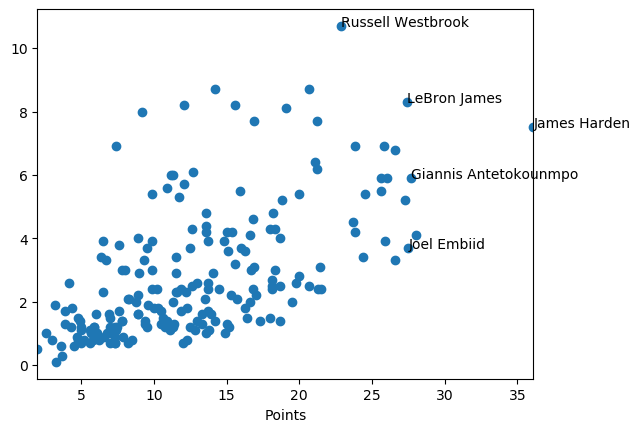

```python
def label_point_2(x, y, val, ax):
        a = pd.concat({'Points': x, 'Assists': y, 'Name': val}, axis=1)
        for i, point in a.iterrows():
            if(point['Name'] == 'Giannis Antetokounmpo' or point['Name'] == 'Joel Embiid' or point['Name'] == 'LeBron James' or point['Name'] == 'James Harden' or point['Name'] == 'Russell Westbrook'):
                ax.text(point['Points'], point['Assists'], str(point['Name']))


Top_200_Players = Complete_Data.head(200)

ax = Top_200_Players.set_index('Points')['Assists'].plot(style='o')
label_point_2(Top_200_Players.Points, Top_200_Players.Assists, Top_200_Players.Name, ax)
fig.canvas.draw()
```

This graph shows that James Harden has more assists and points scored compared to Giannis. There are also many players with more assists compared to Giannis. What is also interesting is that Russell Westbrook clearly has the most assists than Giannis.

# 4. Linear Regression for Attributes on Rating and Votes

Here, there is a comparison between the Ratings of the top 200 Players to the Votes of the top 200 Players. Both utilize attributes regarding player performances. The ratings from NBA 2k19 game are based on player skills. Popular beliefs would point towards the most skilled players being the most popular players. The Linear Regression Analysis below was done to determine whether or not there is a dichotomy between popularity (vote results) and skill rating.

## 4.1 Regression

### Linear Regression Model for Rating:

```python
skills = ['Points','Rebounds','Assists','Blocks','Steals']
player_stats = Top_200_Players[skills]
rating = Top_200_Players[['Rating']]

X = player_stats
y = rating['Rating']
lm = LinearRegression()
model = lm.fit(X, y)
lm.score(X, y)
```

```
0.909699747363472
```

The R-Square for this 0.91. This means that most of the variance for Rating values is explained by this model.

```python
rating_coeffs = lm.coef_.tolist()
for skill, coef in zip(skills, rating_coeffs):
    print("Skill: {}, Coefficient: {}".format(skill,coef))
```

```
Skill: Points, Coefficient: 0.650766581335307
Skill: Rebounds, Coefficient: 0.46155849150258166
Skill: Assists, Coefficient: 0.5278264029711245
Skill: Blocks, Coefficient: 1.431568278183169
Skill: Steals, Coefficient: 0.4498502095293797
```

From the above, it seems that the most important attributes are points per game and blocks per game.

### Linear Regression Model for Votes:

The five skill sets: Points, Rebounds, Assists, Blocks, Steals per game do not affect the Rating. Independent Variables: Points, Rebounds, Assists, Blocks, Steals Dependent Variable: Votes

```python
skills2 = ['Points','Rebounds','Assists','Blocks','Steals']
player_stats2 = Top_200_Players[skills2]
X2 = player_stats2
votes = Top_200_Players[['Votes']]
y2 = votes['Votes']
lf = LinearRegression()
model = lf.fit(X2, y2)
lf.score(X2, y2)
```

```
0.42342770442460553
```

The R-Square for this is 0.42. This means that not a whole lot of Voting values is explained by this model. This indicates there may perhaps be other factors besides players statistics regarding the number of votes.

```python
voting_coeffs = lf.coef_.tolist()
for skill, coef in zip(skills2, voting_coeffs):
    print("Attribute: {}, Coefficient: {}".format(skill,coef))
```

```
Attribute: Points, Coefficient: 3.0954429307395164
Attribute: Rebounds, Coefficient: 0.8709778116592779
Attribute: Assists, Coefficient: 1.855856910685092
Attribute: Blocks, Coefficient: 8.752811770475486
Attribute: Steals, Coefficient: 2.2215398148323953
```

From the above, it seems that the most important attributes are also points per game and blocks per game.

## 4.2 Prediction of Ratings vs Prediction of Votes (Machine Learning)

Here, we predict Ratings and Votes by splitting and training our data to create predictions. We use a test_size of 0.2 for both Ratings and Votes.

## Creating Predictions for Ratings

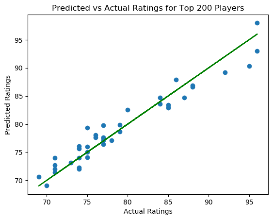

```python
X_train, X_test, y_train, y_test = train_test_split(X, y, test_size=0.2, random_state=0)
rating_regressor = LinearRegression()
prediction_model = rating_regressor.fit(X_train, y_train)
predictions = rating_regressor.predict(X_test)
plt.title("Predicted vs Actual Ratings for Top 200 Players")
plt.scatter(y_test, predictions)
plt.plot(y_test, y_test, color="green")
plt.xlabel("Actual Ratings")
plt.ylabel("Predicted Ratings")
```

```python
print("On scale from 0 to 1, the number to the right is how accurate the model predicts Ratings: ", prediction_model.score(X_test, y_test))
```

```
On scale from 0 to 1, the number to the right is how accurate the model predicts Ratings:  0.9333319617975457
```

As you can observe, the model predicted the Top Player ratings rather well.

## Creating Predictions for Votes

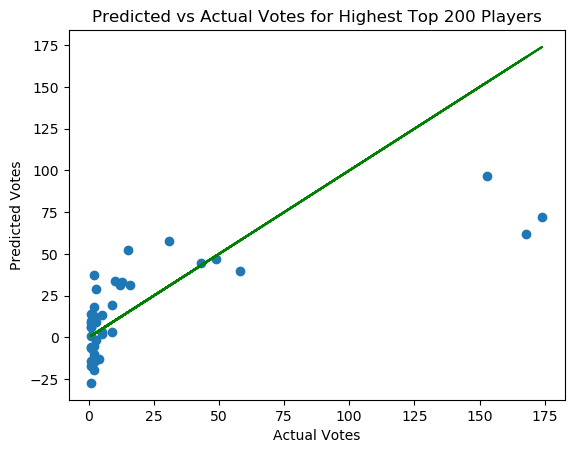

```python
X_train, X_test, y_train, y_test = train_test_split(X2, y2, test_size=0.2, random_state=0)
rating_regressor = LinearRegression()
prediction_model = rating_regressor.fit(X_train, y_train)
predictions = rating_regressor.predict(X_test)
plt.title("Predicted vs Actual Votes for Highest Top 200 Players")
plt.scatter(y_test, predictions)
plt.plot(y_test, y_test, color="green")
plt.xlabel("Actual Votes")
plt.ylabel("Predicted Votes")
```

Here you can observe that the model does not seem to accurately predict number of Votes for each player.

```python
print("On scale from 0 to 1, the number to the right is how accurate the model predicts Votes: ", prediction_model.score(X_test, y_test))
```

```
On scale from 0 to 1, the number to the right is how accurate the model predicts Votes:  0.5381702630739227
```

# 5. Conclusion

## 5.1: Top 200 Players

From an analysis on the top 200 players, the top 10 players with the top votes tend to have top attribute values compared to the average attribute values of the top 200 players. This points towards the idea that the most voted players also tend to be the best performing players. Also an analysis was done on conference area performance where it was indicated that the differences were rather minute in terms of skill level.

## 5.2: Potential Outliers

From an analysis on the outliers, it seems that Giannis Antetokounmpo has significantly more votes than similar performing players. This indicates that there may perhaps be other factors beyond basketball skill attributes such as popularity, media coverage, etc.

## 5.3: Regression Analysis (Ratings vs Votes)

The Regression Analysis above indicates that the Linear Regression Models predicted the Top Players ratings rather accurately. However, the Linear Regression Models seem to not predict the Top Player Votes accurately. This indicates that there are interaction terms besides skillsets that predict or indicate popularity (Votes).

In general, the top voted players are what you expect, the top rated or most skillful players. On the other hand, the outliers and the fact that the skill attributes don't predict Votes as much as Ratings signal external interaction terms that are not included in a basketball player's skillset, but rather other factors related to popularity.

The CSV files used can be found at: https://github.com/rlin964080/rlin964080.github.io